# bulk_DGE_tutorial

2026-04-03

## R Basics

R software is available here: https://cran.r-project.org/

R Studio IDE can be downloaded here https://posit.co/download/rstudio-desktop/

Packages/tools can be downloaded from the CRAN

Specific bioinformatics tools can be downloaded from Bioconductor https://www.bioconductor.org/

First let’s set our working directory so we can export/import files from on our computer Session -> Set Working Directory -> Choose Directory

Now let’s load our example data

Calling this will give us an “ExpressionSet” Object that we will pull counts from

```r
data(pickrell1)

?pickrell
```

this will store the counts as a matrix for us to work with

```r
Counts <- exprs(pickrell1.eset)
```

running this or clicking “Counts” in our Environment will let us see what the matrix looks like

```
##                 NA18486 NA18498 NA18499 NA18501 NA18502 NA18504 NA18505 NA18507
## ENSG00000127720       6      32      14      35      14      10      23      19
## ENSG00000242018      20      21      24      22      16      13      11       6
## ENSG00000224440       0       0       0       0       0       0       0       0
## ENSG00000214453       0       0       0       0       0       0       0       0
## ENSG00000237787       0       0       1       0       0       1       0       0
## ENSG00000051596     408     475     220     294     325     224     450     711
##                 NA18508 NA18510 NA18511 NA18516 NA18517 NA18519 NA18520 NA18522
## ENSG00000127720      16      10      32      30      18      15      13      30
## ENSG00000242018      19      19      25      18      40      32      25      27
## ENSG00000224440       0       0       0       0       0       0       0       0
## ENSG00000214453       0       0       0       0       0       0       0       0
## ENSG00000237787       0       0       0       0       0       0       0       0
## ENSG00000051596     585     514     431     399     720     505     507     758
##                 NA18523 NA18852 NA18853 NA18855 NA18856 NA18858 NA18861 NA18862
## ENSG00000127720       5      20      11      12      18      23      22      37
## ENSG00000242018      18      20      16      28       4      19      11      19
## ENSG00000224440       0       0       0       0       0       0       1       0
## ENSG00000214453       0       0       0       0       0       0       0       0
## ENSG00000237787       0       0       0       0       0       0       0       0
## ENSG00000051596     210     365     192     599     244     295     256     310
##                 NA18870 NA18871 NA18909 NA18912 NA18913 NA18916 NA19093 NA19098
## ENSG00000127720      23      15      21      15       8      29      22      17
## ENSG00000242018      16      19      18       7      40      20      28      34
## ENSG00000224440       0       0       0       0       0       0       0       0
## ENSG00000214453       0       0       0       0       0       0       0       0
## ENSG00000237787       0       0       0       0       0       0       0       0
## ENSG00000051596     231     149     389     113     450     273     322     770
##                 NA19099 NA19101 NA19102 NA19108 NA19114 NA19116 NA19119 NA19127
## ENSG00000127720      22      35       6      36      10      23       6      16
## ENSG00000242018      27      37       5      21      15      32       8      12
## ENSG00000224440       0       0       0       0       0       0       0       0
## ENSG00000214453       0       0       0       0       0       0       0       0
## ENSG00000237787       0       1       0       0       0       0       0       0
## ENSG00000051596     548     336     131     598     264     416     120     624
##                 NA19128 NA19130 NA19131 NA19137 NA19138 NA19140 NA19143 NA19144
## ENSG00000127720      17      35      17      15      16      13      14       6
## ENSG00000242018      18      14      35      20      31      11      32      56
## ENSG00000224440       0       0       0       0       0       0       1       0
## ENSG00000214453       0       0       0       0       0       0       1       0
```

[output cut: 8 more lines]

```
## ENSG00000051596     380     621     432     238     363     276     280     240
##                 NA19192 NA19193 NA19200 NA19201 NA19203 NA19204 NA19209 NA19210
## ENSG00000127720      10      11      13      22      12      23      12      11
## ENSG00000242018      28       8      11      27      16      18      38      32
## ENSG00000224440       0       0       0       0       0       0       0       0
## ENSG00000214453       0       0       0       0       0       0       0       0
## ENSG00000237787       3       0       0       0       0       0       0       0
## ENSG00000051596     424     471     258     287     549     293     534     851
##                 NA19222 NA19225 NA19238 NA19239 NA19257
## ENSG00000127720      19      27      35      50      23
## ENSG00000242018       6      13      12      22      26
## ENSG00000224440       0       0       0       0       0
## ENSG00000214453       0       0       1       0       0
## ENSG00000237787       0       0       3       0       0
## ENSG00000051596     392     481     504     568     450
```

Counts is our R Object For indexing we use square brackets [] In an R matrix or dataframe, we call: OBJECT[rows, columns] We can call individual rows/columns or a set of rows/columns by using a colon

Running this will give us the first five rows and columns of the data and show us in our Console

```r
Counts[1:5,1:5]
```

```
##                 NA18486 NA18498 NA18499 NA18501 NA18502
## ENSG00000127720       6      32      14      35      14
## ENSG00000242018      20      21      24      22      16
## ENSG00000224440       0       0       0       0       0
## ENSG00000214453       0       0       0       0       0
## ENSG00000237787       0       0       1       0       0
```

this gives us the dimensions of our matrix, we have 38,415 rows/genes and 69 columns/samples

```r
dim(Counts)
```

```
## [1] 38415    69
```

Note that the rows are gene names that use ENSEMBL Gene IDs and Columns are samples

This example wants to look at DGE differences in sex since we have that information stored the ExpressionSet object has metadata information that is stored/accessed using the ‘$’

Dataframes and some list objects can be queried using ‘$’, which typically refers to a column This will give us a vector that is considered a category with two levels (male/female)

```r
Gender <- pickrell1.eset$gender
```

Since this is a vector (1 dimension), we can use length() to see that this matches the number of samples in our matrix

```r
length(Gender)
```

```
## [1] 69
```

Note that the “length” of this vector matches the columns of our matrix

We can also see what the first 5 observations look like There’s no need to use a comma because this is only in 1-dimension

```r
Gender[1:5]
```

```
## [1] male   male   female male   female
## Levels: female male
```

Note that we have “Levels”, which mean this is a factor() or category that has been labeled already. It tells us that our categories are female and male. table() will summarize how many males and females make up this vector

```r
table(Gender)
```

```
## Gender
## female   male
##     40     29
```

Now we’re ready to make our DGEList object that is required for edgeR The data must be integer counts (no fractions/proportions) and the rownames must be set as the gene names/symbols for it to run

```r
#This has information regarding Ensembl IDs and their corresonding gene symbols
#We will use this to index our DGEList object, to make sure we're only analyzing genes that have annotations
data(annotEnsembl63)
annot <- annotEnsembl63[,c("Symbol","Chr")]
rm(annotEnsembl63)

#This was taken from another tutorial that used limma/voom
#We're only going to use this step to make a vector of genes that aren't missing
y <- DGEList(counts=Counts, group=Gender,genes=annot[rownames(Counts),])
hasannot <- rowSums(is.na(y$genes))==0
```

## DGE Example - DESeq2

```r
library(DESeq2)
df_key = cbind.data.frame(colnames(Counts),Gender )
names(df_key) = c("Sample","Gender")

head(df_key)
```

```
##    Sample Gender
## 1 NA18486   male
## 2 NA18498   male
## 3 NA18499 female
## 4 NA18501   male
## 5 NA18502 female
## 6 NA18504   male
```

Normalizing to housekeeping genes tends to give more stable estimates

```r
housekeeping_genes = c("ABCF1",
                       "ACTB",
                       "ALAS1",
                       "B2M",
                       "CLTC",
                       "G6PD",
                       "GAPDH",
                       "GUSB",
                       "HPRT1",
                       "LDHA",
                       "PGK1",
                       "POLR1B",
                       "POLR2A",
                       "RPL19",
                       "RPLP0",
                       "SDHA",
                       "TBP",
                       "TUBB")

housekeeping_ENS = rownames(annot[annot$Symbol %in% housekeeping_genes,])
```

Let’s see if data separate out by our condition by using PCA

```r
pca_plot = function(df,key){

  #df = Counts+1
  #key = df_key

  #making sure we're only using genes that have annotations
  df = df[hasannot,]

  #cleaning up the category in case there happens to be unwanted white space
  key$Gender = trimWhiteSpace(key$Gender)

  #Gender analysis
  ds <- DESeqDataSetFromMatrix(countData=round(df), colData=key, design= ~Gender)
  ds$Gender <- relevel(ds$Gender,"female") #keeping our reference groups consistent
  isControl <- rownames(ds) %in% housekeeping_ENS
  ds = estimateSizeFactors(ds,controlGenes=isControl)
  dds <- DESeq(ds)

  #see steps here: https://bioconductor.org/packages/release/workflows/vignettes/rnaseqGene/inst/doc/rnaseqGene.html#pca-plot

  #applying modeling corrections with this
  vst <-vst(dds,blind=F)

  pcaData <- plotPCA(vst, intgroup = c( "Gender"),pcsToUse = c(1,2) ,returnData = TRUE,ntop=50)
  percentVar <- round(100 * attr(pcaData, "percentVar"))

  #this seems to separate CAR and cycle variation
  pca_gender_pc1_pc2 = ggplot(pcaData, aes(x = PC1, y = PC2, color = Gender)) +
    geom_point(size =3) +
    scale_color_manual(values=c("#0000ff","#00ff00"),name="Sex") +
    xlab(paste0("PC1: ", percentVar[1], "% variance")) +
    ylab(paste0("PC2: ", percentVar[2], "% variance")) +
    coord_fixed() +
    theme_bw()

  #sometimes other PCs might give better separation
  pcaData <- plotPCA(vst, intgroup = c( "Gender"),pcsToUse = c(1,3) ,returnData = TRUE,ntop=50)
  percentVar <- round(100 * attr(pcaData, "percentVar"))

  #this seems to separate CAR and cycle variation
  pca_gender_pc1_pc3 = ggplot(pcaData, aes(x = PC1, y = PC3, color = Gender)) +
    geom_point(size =3) +
    scale_color_manual(values=c("#0000ff","#00ff00"),name="Sex") +
    xlab(paste0("PC1: ", percentVar[1], "% variance")) +
    ylab(paste0("PC3: ", percentVar[2], "% variance")) +
    coord_fixed() +
    theme_bw()

  pcaData <- plotPCA(vst, intgroup = c( "Gender"),pcsToUse = c(1,4) ,returnData = TRUE,ntop=50)
  percentVar <- round(100 * attr(pcaData, "percentVar"))

  #this seems to separate CAR and cycle variation
  pca_gender_pc1_pc4 = ggplot(pcaData, aes(x = PC1, y = PC4, color = Gender)) +
    geom_point(size =3) +
    scale_color_manual(values=c("#0000ff","#00ff00"),name="Sex") +
    xlab(paste0("PC1: ", percentVar[1], "% variance")) +
    ylab(paste0("PC4: ", percentVar[2], "% variance")) +
    coord_fixed() +
    theme_bw()

  return(list("pca_gender_pc1_pc2" = pca_gender_pc1_pc2,
              "pca_gender_pc1_pc3" = pca_gender_pc1_pc3,
              "pca_gender_pc1_pc4" = pca_gender_pc1_pc4

  ))


}

pca_figures = pca_plot(Counts,df_key)
```

```
## -- replacing outliers and refitting for 233 genes
## -- DESeq argument 'minReplicatesForReplace' = 7
## -- original counts are preserved in counts(dds)
```

```
## using ntop=50 top features by variance
## using ntop=50 top features by variance
## using ntop=50 top features by variance
```

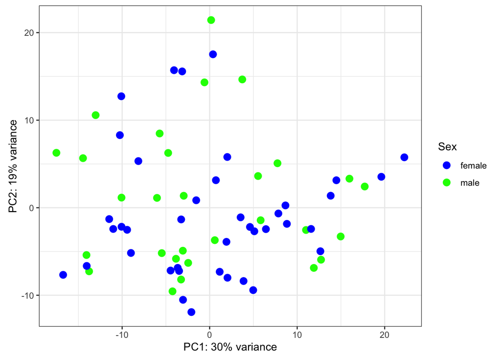

```r
pca_figures$pca_gender_pc1_pc2
```

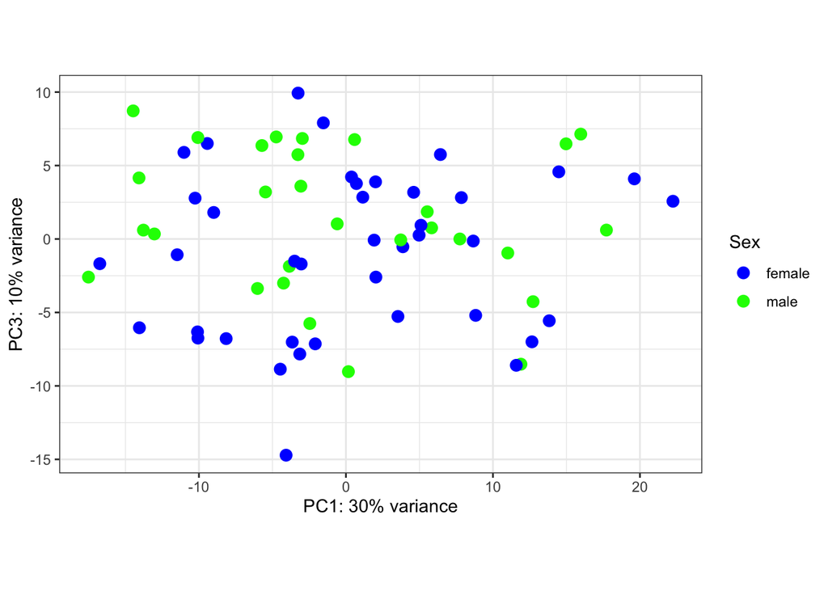

```r
pca_figures$pca_gender_pc1_pc3
```

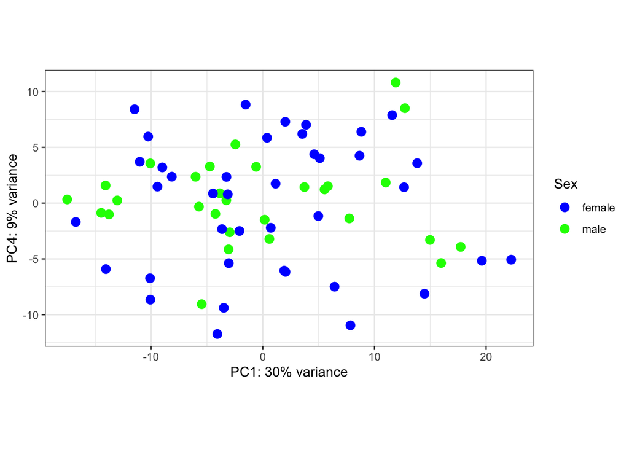

```r
pca_figures$pca_gender_pc1_pc4
```

There doesn’t seem to be great separation, however, PCAs are just descriptive representations. This doesn’t mean there aren’t relevant DEGs. PCA is NOT a hypothesis test! Try not to over-interpret anything from a PCA.

Now we can export whichever PCA plot we want.

```r
ggsave(
  "PCA_PC1_PC2.png",
  pca_figures$pca_gender_pc1_pc2,
  width = 10,
  height = 10,
  dpi = 300,
  device="png"
)
```

```r
dge_deseq2 = function(df,key){
  #df = Counts
  #key = df_key

  #making sure we're only using genes that have annotations
  df = df[hasannot,]

  #cleaning up the category in case there happens to be unwanted white space
  key$Gender = trimWhiteSpace(key$Gender)

  #Gender analysis
  ds <- DESeqDataSetFromMatrix(countData=round(df), colData=key, design= ~Gender)
  ds$Gender <- relevel(ds$Gender,"female") #keeping our reference groups consistent
  isControl <- rownames(ds) %in% housekeeping_ENS
  ds = estimateSizeFactors(ds,controlGenes=isControl)
  ds <- DESeq(ds)
  #resultsNames(ds)
  dge_gender = as.data.frame(results(ds, contrast=list(c("Gender_male_vs_female")), test="Wald",pAdjustMethod = "BH"))

  #merge this with the count table like we did before

  dge_gender_full = transform(merge(dge_gender,annot,by="row.names"),row.names=Row.names,Row.names=NULL)


  results = list("Gender_DESeq2" = dge_gender_full,
                     "counts" = df[order(Gender),]
  )

  return(results)



}

deseq2_output = dge_deseq2(Counts+1,df_key)
```

```
## -- replacing outliers and refitting for 204 genes
## -- DESeq argument 'minReplicatesForReplace' = 7
## -- original counts are preserved in counts(dds)
```

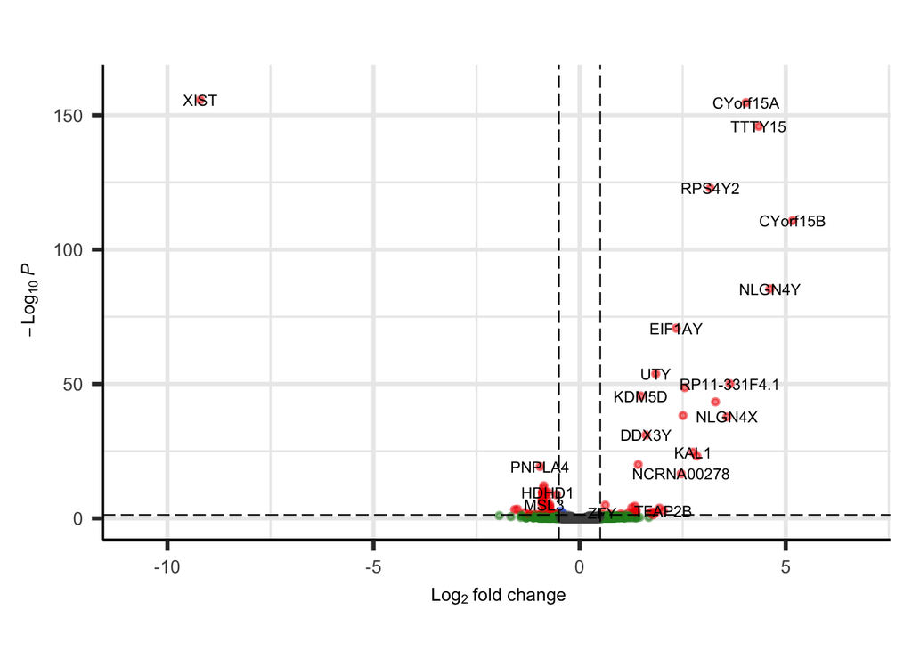

```r
deseq2_volcano = EnhancedVolcano(deseq2_output$Gender_DESeq2,
                lab = deseq2_output$Gender_DESeq2$Symbol,
                x = 'log2FoldChange',
                y = 'padj',
                pCutoff = 0.05,
                FCcutoff = .5,
                pointSize = 1.0,
                labSize = 3.0,
                legendLabels=c('NS','Log2FC','p-value',
                               'p-value & Log2FC'),
                legendPosition = 'none',
                legendLabSize = 10,
                legendIconSize = 1,
                axisLabSize = 10,
                title = "",
                subtitle = "",
                caption = "",
                titleLabSize = 0,
                subtitleLabSize = 0,
                captionLabSize = 0)
deseq2_volcano
```

Unsurprisingly, the right side of the plot is a Y chrom associated gene annotation the left side is an X chrom associated gene annotation. Since we defined our reference as “female” this means that the up-regulated genes are those that are higher in males compared to females.

Export output of interest

```r
write.xlsx(deseq2_output$Gender_DESeq2,"DESeq2_output.xlsx")
```

```r
ggsave(
  "volcano_DESeq2.png",
  deseq2_volcano,
  width = 10,
  height = 10,
  dpi = 300,
  device="png"
)
```